# Поиск файлов и фильтрация текстовых данных

Отчет по лабораторной работе №8

Садыков Ильдар Ильфатович

2026-03-19

# Цель работы

Ознакомление с инструментами поиска файлов и фильтрации текстовых данных. Приобретение практических навыков по управлению процессами, по проверке использования диска и обслуживанию файловых систем.

# Задание

Выполнить действия по перенаправлению ввода-вывода, поиску файлов, фильтрации текста, управлению процессами и проверке использования диска.

# Выполнение лабораторной работы

## Вход в систему

Осуществлён вход в систему под учётной записью пользователя.

[figure not shown]

## Запись названий файлов в file.txt

- Выполнена запись названий файлов из каталога /etc в файл file.txt
- В этот же файл дописаны названия файлов из домашнего каталога

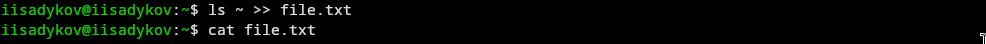

Запись названий файлов

## Поиск файлов с расширением .conf

- Из файла file.txt выделены все файлы с расширением .conf
- Результат записан в новый файл conf.txt

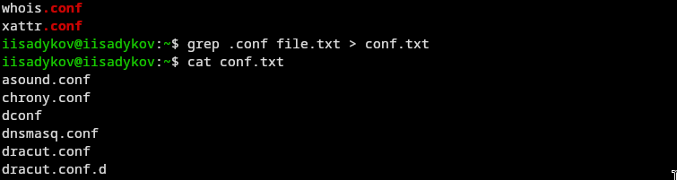

Поиск .conf файлов

## Поиск файлов, начинающихся с символа с

В домашнем каталоге найдены файлы, имена которых начинаются с символа с. Использованы различные варианты команды find.

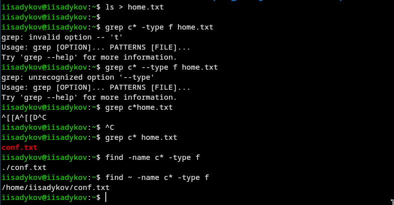

Поиск файлов, начинающихся с ‘с’

## Поиск файлов в каталоге /etc, начинающихся с h

Выведены на экран имена файлов из каталога /etc, начинающиеся с символа h.

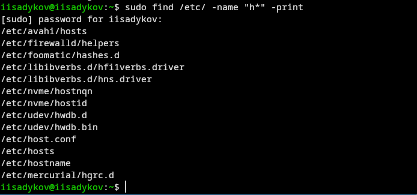

Поиск файлов, начинающихся с ‘h’

## Запуск фонового процесса и удаление файла

- Запущен в фоновом режиме процесс, записывающий в файл ~/logfile файлы с именами, начинающимися на log
- Затем файл ~/logfile удалён

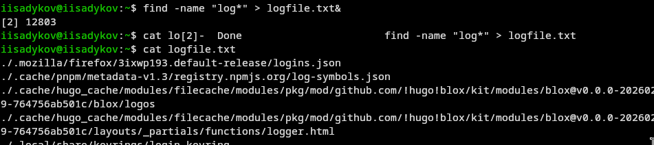

## Работа с редактором gedit

- Запущен в фоновом режиме редактор gedit
- С помощью команд ps и grep определён идентификатор процесса gedit
- Изучена команда kill, с её помощью завершён процесс gedit

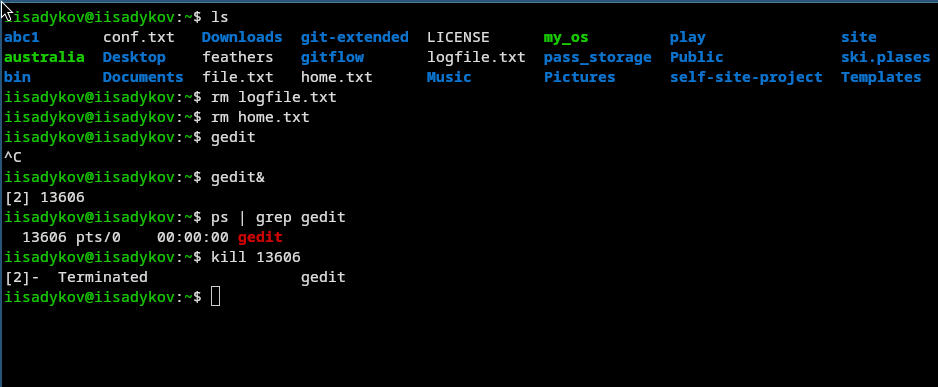

Работа с gedit и управление процессом

## Команды df и du

- Изучена справочная информация о командах df и du с помощью man
- Выполнен вывод информации об использовании диска

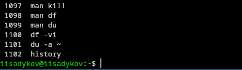

## Поиск всех директорий в домашнем каталоге

С помощью команды find выведены имена всех директорий, имеющихся в домашнем каталоге.

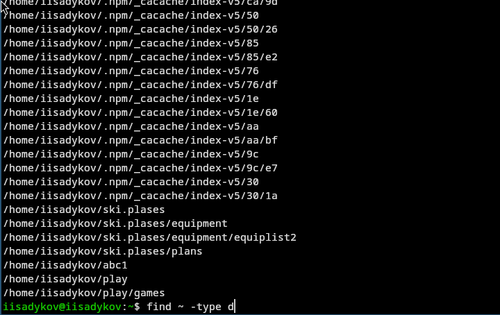

Поиск директорий в домашнем каталоге

# Выводы

В ходе работы освоены инструменты поиска файлов и фильтрации текстовых данных, приобретены навыки управления процессами, проверки использования диска и обслуживания файловых систем.